# Lab 02 - Intro to R Markdown

The main goal of this lab is to introduce you to R Markdown, and see how we can use it to produce lab reports for our course.

# 1 What is R Markdown?

R Markdown is a file format for making dynamic documents with R. R Markdown can combine your code, its results, and your prose, into a single document. R Markdown documents are fully reproducible and support dozens of output formats, like PDF, Word files, slideshows and webpages, among others.

R Markdown was initially created to generate documents that serve as a neat record of your analysis, a bit like a notebook. So, instead of commenting extensively the code script, RMarkdown presents your code alongside its output (graphs, tables, etc.) with conventional text to explain it. Over time, R Markdown has proven useful for use in three main ways (Grolemund and Wickham, 2016):

1. For collaborating with other data scientists (including future you!), who are interested in both your conclusions, and how you reached them ( i.e. the code).
2. For communicating to decision makers, who want to focus on the conclusions, not the code behind the analysis.
3. As an environment in which to do data science, as a modern day lab notebook where you can capture not only what you did, but also what you were thinking.

R Markdown is based on Markdown, a coding language that allows for text-to-HTML conversion. It was originally designed for web developers to allow for editing of web pages with an easy-to-read and easy-to-write plain text format. Due to it’s basic nature, you need none to very little programming knowledge in order to write in Markdown. R Markdown is a variation on Markdown allowing it to be implemented in R. So an R Markdown document is simply a document written in Markdown that contains chunks of embedded R code.

In the context of our course, we will use R Markdown documents to create nice, self-explaining lab reports in which you can describe the reasoning and the steps you followed to answer the exercises, provide the code you used and show the output of that code.

[figure not shown]

*Example of an R Markdown document. On the left, the .Rmd file. On the right, the generated .html file*

Since it was initially developed, many extensions and R packages have been created to get the most out of the R Markdown features. R Markdown documents can now be used to produce a wide range of output file types: pdf, doc, html. The versatility of the html language makes it possible to produce many types of documents, including reports, slides for a presentation, websites, interactive panels, and even complete online books!! To give you an idea, all the slides for the lectures, the labs documents, or even the course website have all been generated using R Markdown. You can see more examples of nice applications for R Markdown [here](https://rmarkdown.rstudio.com/gallery.html)

**EXERCISE 1:**  
Take a look at the [RMarkdown Gallery](https://rmarkdown.rstudio.com/gallery.html) and tell me some of the most striking examples you have found

# 2 Using RMarkdown in RStudio

The benefits of R Markdown are best appreciated when using it within RStudio (or RStudio Cloud). From RStudio, you can easily create a new R Markdown file by going to the “New File” symbol in the top left hand corner and select “R Markdown”.

[figure not shown]

The following window then asks you for a title, the author and what format you’d like the final rendered file to be. All of these elements can be changed later if you change your mind. You can also see from the left hand tab that R Markdown can be used to make other things besides documents, including presentations and shiny apps. For now, give the document an appropriate title, indicate your name, and choose “HTML” as the output format:

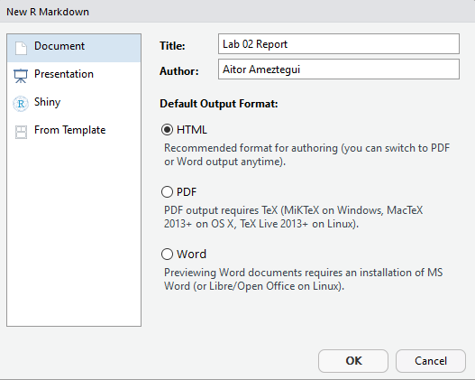

The new R Markdown file - which is actually a plain text file with the extension `.Rmd` - should now have opened on the left hand side, above the console window.

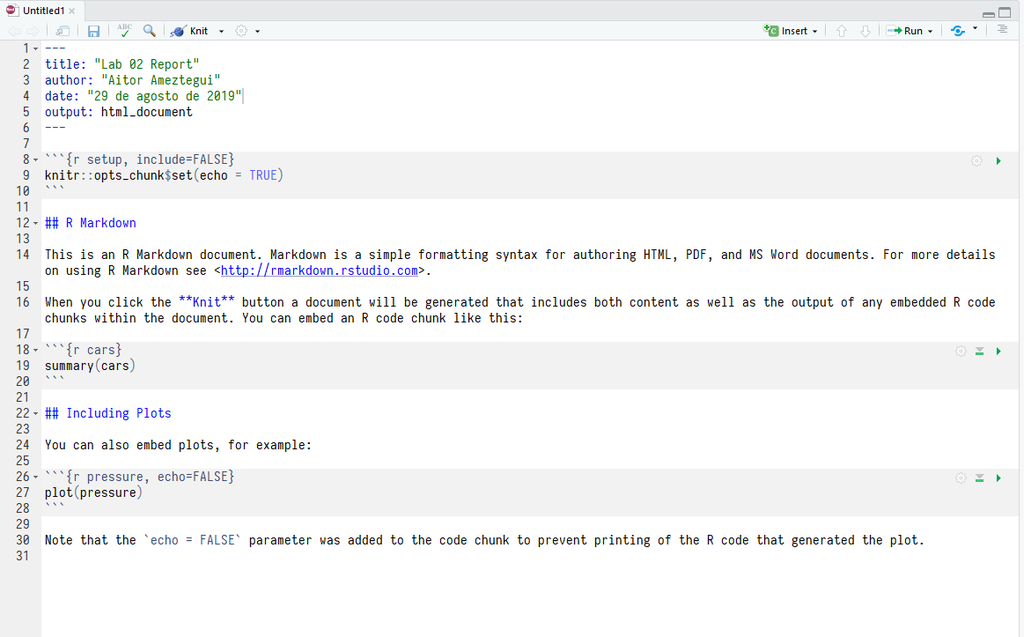

It mainly has three parts:

1. An (optional) YAML header at the top of the page, surrounded between two lines of three dashes (`---`)
2. Chunks of R code surrounded by `` ``` ``
3. Text mixed with formated text like `**bold**` and `## headers`.

When opening an `.Rmd` file, code, text and output are interleaved. You can run each code chunk by clicking the Run icon (a play button at the top of the chunk), or by pressing `Cmd/Ctrl` + `Shift` + `Enter`. RStudio executes the code and displays the results inline with the code:

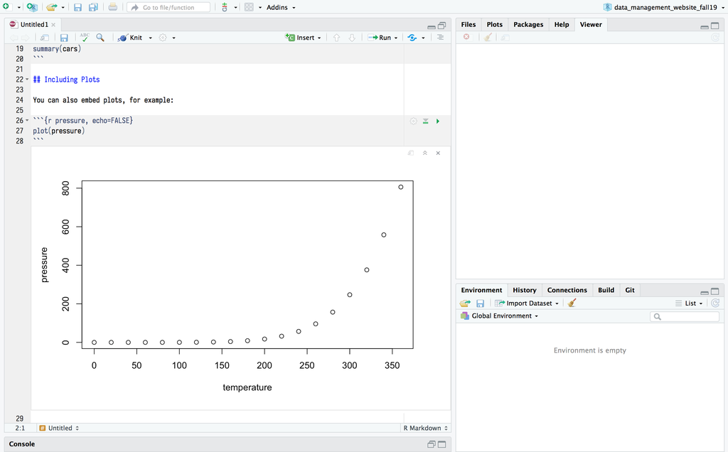

To produce a complete report containing all text, code, and results, click “Knit” or press `Cmd/Ctrl` + `Shift` + `K`. This will display the report in the viewer pane, and create a self-contained HTML file that you can share with others.

**EXERCISE 2:**

1. Create a new notebook using File > New File > R Markdown. Change the title of the document to “First Test with RMarkdown”, and set the author field with your name. Save the file as “first_test.Rmd”. Then practice running the code chunks. Modify the code of some of the chunks, re-run the chunk and see how the output changes. Finally, knit the whole document into an html file.
2. Create one new R Markdown document for each of the three built-in formats: HTML, PDF and Word. Knit each of the three documents. How does the output differ? How does the input differ? (You may need to install LaTeX in order to build the PDF output — RStudio will prompt you if this is necessary.) -if you have problems to knit the PDF version don’t worry and continue with the lab.